# assignment.Rmd

tgermade

2023-03-30

```r
suppressPackageStartupMessages({
  library(ensembldb)
  library(GenomicRanges)
  library(epiwraps)
  library(rtracklayer)
  library(ggplot2)
})
```

```r
setwd("../week04/")
# import
samples.n <- c("p300", "H3K4me3", "H3K4me1", "H3K27ac", "H3K27me3")
beds <- list.files(pattern = ".narrowPeak.bed")
samples.l <- GRangesList()

for(x in samples.n){
  file <- beds[grepl(x, beds)]
  samples.l[[x]] <- rtracklayer::import(file, format="narrowPeak")
}
```

```r
regionOverlaps(samples.l)
# overlap coeff: proportion of union that is in the intersection
# asymmetry of overlap functions!
```

[output not shown]

```r
regionUpset(samples.l, reference= samples.l$H3K27me3, nsets= length(samples.l))
# only shows p300 related regions
```

[output not shown]

```r
id.k4 <- overlapsAny(samples.l$H3K4me3, samples.l$H3K27me3)
id.k27 <- overlapsAny(samples.l$H3K27me3, samples.l$H3K4me3)
table(id.k4)
```

```
## id.k4
## FALSE  TRUE
## 48905  3594
```

```r
table(id.k27)
```

```
## id.k27
## FALSE  TRUE
## 11943  4705
```

```r
biv.k4 <- samples.l$H3K4me3[id.k4]
biv.k27 <- samples.l$H3K27me3[id.k27]
```

# Tri-Methylation Comparison: ES cells vs. Neural progenitor cells

I chose the earliest neuronal tube ChIPseq assay I could find on Encode, when the neural tube is closed and the neuroepithelial cells give rise to neural progenitor cells. Sources: 1) https://www.frontiersin.org/articles/10.3389/fnana.2018.00104/full; 2) https://www.ncbi.nlm.nih.gov/pmc/articles/PMC4023228/  
Using ENCODE 3 mm10 samples for consistency with the ESC data.

```r
download.file("https://www.encodeproject.org/files/ENCFF232UTI/@@download/ENCFF232UTI.bed.gz", "H3K4me3_neuraltube_mm10_chip.narrowPeak.bed.gz")
download.file("https://www.encodeproject.org/files/ENCFF090NYW/@@download/ENCFF090NYW.bed.gz", "H3K27me3_neuraltube_mm10_chip.narrowPeak.bed.gz")
```

```r
# unzip
for(x in list.files(pattern = ".narrowPeak.bed.gz")){
  R.utils::gunzip(x)
}
```

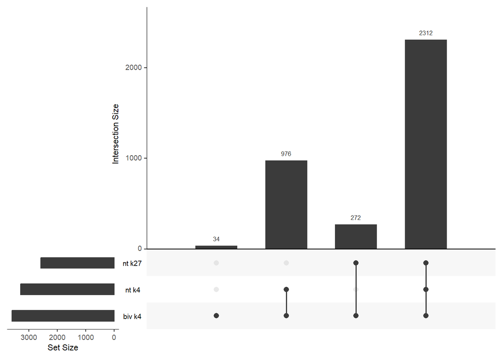

```r
# import
samples.nt.n <- c("H3K27me3", "H3K4me3")
beds <- list.files(pattern = ".narrowPeak.bed")
samples.nt.l <- GRangesList()

for(x in samples.nt.n){
  file <- beds[grepl(x, beds)]
  samples.nt.l[[x]] <- rtracklayer::import(file, format="narrowPeak")
}

sample.comp.l <- c(biv.k4=biv.k4, biv.k27=biv.k27, nt.k4=samples.nt.l$H3K4me3,
                             nt.k27=samples.nt.l$H3K27me3)


regionUpset(sample.comp.l[-2], reference= sample.comp.l$biv.k4, nsets= length(sample.comp.l[-2]))
```

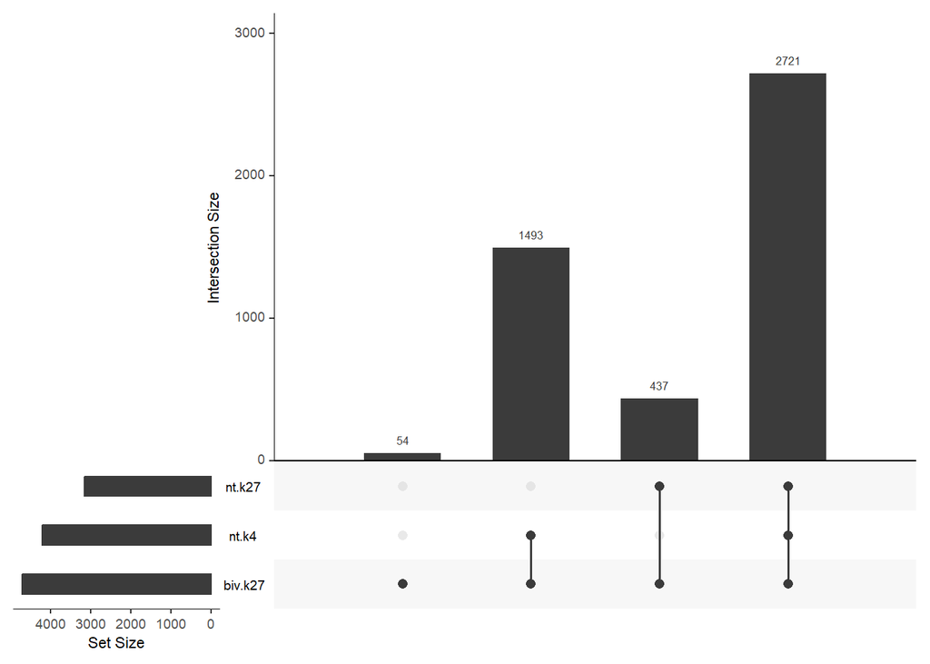

```r
regionUpset(sample.comp.l[-1], reference= sample.comp.l$biv.k27, nsets= length(sample.comp.l[-1]))
```

Based on ESC H3K4me3: There are 976 bivalent domains in mouse ES cells that are overlapping the H3K4me3 domains of a mouse neural tube sample. There are 272 bivalent domains in ESCs that overlap H3K27me3 domains in neural tube. There are 2312 bivalent domains in ESCs that remain bivalent in neural tube.

Based on ESC H3K27me3: There are 1493 bivalent domains in mouse ES cells that are overlapping the H3K4me3 domains of a mouse neural tube sample. There are 437 bivalent domains in ESCs that overlap H3K27me3 domains in neural tube. There are 2721 bivalent domains in ESCs that remain bivalent in neural tube.

# Percentages

```r
ol.all_k4 <- sum(sum(overlapsAny(biv.k4, samples.nt.l$H3K4me3)))
ol.all_k27 <- sum(sum(overlapsAny(biv.k4, samples.nt.l$H3K27me3)))
ol.shared <- sum(overlapsAny(biv.k4[overlapsAny(biv.k4, samples.nt.l$H3K27me3)], samples.nt.l$H3K4me3))

# percent of bivalent domains that remain bivalent in NT
p.biv <- ol.shared / length(biv.k4) * 100
# percent of bivalent domains that overlap with H3K4me3 in NT
p.k4 <- (ol.all_k4 - ol.shared) / length(biv.k4) * 100
# percent of bivalent domains that overlap with H3K27me3 in NT
p.k27 <- (ol.all_k27 - ol.shared) / length(biv.k4) * 100
# percent of bivalent domains that weren't found in NT
p.gone <- (length(biv.k4) - (ol.shared +
                (ol.all_k4 - ol.shared) + (ol.all_k27 - ol.shared)
                )) / length(biv.k4) * 100
p <- lapply(c(p.biv, p.k4, p.k27, p.gone), round, 1)
names(p) <- c("biv", "k4", "k27", "gone")
```

Here just for the case of bivalent domains in ESCs based on H3K4me3:  
Domains that remain bivalent in NT: 64.3 %  
Domains that overlap H3K4me3 in NT: 27.2 %  
Domains that overlap H3K27me3 in NT: 7.6 %  
Domains that do not overlap in NT: 0.9 %